# The Best Classifier

## Final Project in Machine Learning with Python

#### 2020.10.03

This is a predictive modeling project of loan classification using select machine learning algorithms.

I. Setup and II. Pre-Processing were [provided by the course](https://cf-courses-data.s3.us.cloud-object-storage.appdomain.cloud/IBMDeveloperSkillsNetwork-ML0101EN-SkillsNetwork/labs/FinalModule_Coursera/ML0101EN-Proj-Loan-py-v1.ipynb). I modified a few aspects to fit my style, such as section labeling, modifying graphs, as well as variable naming conventions in Python, and editing the dataframe column names.

III. Classification, IV. Scoring, and V. Appendix were coded by me.

## I. Setup

### 1. Packages

```python
import matplotlib.pyplot as plt
import pandas as pd
import numpy as np
import seaborn as sns
from sklearn import preprocessing

%matplotlib inline
```

### 2. About the Dataset

This dataset is about past loans. The **loan_train.csv** data set includes details of 346 customers whose loan are already paid off or defaulted. It includes following fields:

| Field | Description |
| --- | --- |
| Loan_status | Whether a loan is paid off on in collection |
| Principal | Basic principal loan amount at the |
| Terms | Origination terms which can be weekly (7 days), biweekly, and monthly payoff schedule |
| Effective_date | When the loan got originated and took effects |
| Due_date | Since it’s one-time payoff schedule, each loan has one single due date |
| Age | Age of applicant |
| Education | Education of applicant |
| Gender | The gender of applicant |

### 3. Load Data From CSV File

```python
import wget

url = "https://s3-api.us-geo.objectstorage.softlayer.net/cf-courses-data/CognitiveClass/ML0101ENv3/labs/loan_train.csv"
filename = wget.download(url)
df = pd.read_csv(filename)
```

```
100% [..............................................................................] 23101 / 23101
```

### 4. Convert to Datetime Object

```python
df['due_date'] = pd.to_datetime(df['due_date'])
df['effective_date'] = pd.to_datetime(df['effective_date'])
df.head()
```

|  | Unnamed: 0 | Unnamed: 0.1 | loan_status | Principal | terms | effective_date | due_date | age | education | Gender |
| --- | --- | --- | --- | --- | --- | --- | --- | --- | --- | --- |
| 0 | 0 | 0 | PAIDOFF | 1000 | 30 | 2016-09-08 | 2016-10-07 | 45 | High School or Below | male |
| 1 | 2 | 2 | PAIDOFF | 1000 | 30 | 2016-09-08 | 2016-10-07 | 33 | Bechalor | female |
| 2 | 3 | 3 | PAIDOFF | 1000 | 15 | 2016-09-08 | 2016-09-22 | 27 | college | male |
| 3 | 4 | 4 | PAIDOFF | 1000 | 30 | 2016-09-09 | 2016-10-08 | 28 | college | female |
| 4 | 6 | 6 | PAIDOFF | 1000 | 30 | 2016-09-09 | 2016-10-08 | 29 | college | male |

## II. Pre-Processing

Exploring the number of a few classes in the data set.

### 1. Dependent Variable

```python
df['loan_status'].value_counts()
```

```
PAIDOFF       260
COLLECTION     86
Name: loan_status, dtype: int64
```

### 2. Gender

#### a. By Principal Amount

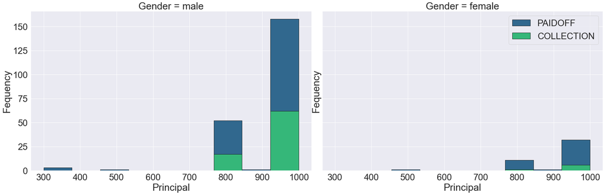

```python
bins = np.linspace(df.Principal.min(), df.Principal.max(), 10)
sns.set(font_scale = 2.5)
g = sns.FacetGrid(df,
                  col = "Gender",
                  hue = "loan_status",
                  palette = "viridis",
                  col_wrap = 2,
                  height = 9,
                  aspect = 13 / 9)
g.map(plt.hist,
      'Principal',
      bins = bins,
      ec = "k")
g.set(ylabel = "Fequency")
g.axes[-1].legend();
```

#### b. By Age

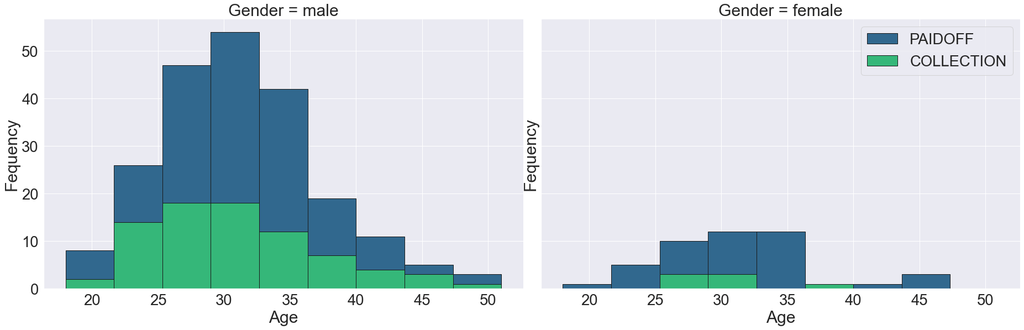

```python
bins = np.linspace(df.age.min(), df.age.max(), 10)
sns.set(font_scale = 2.5)
g = sns.FacetGrid(df,
                  col = "Gender",
                  hue = "loan_status",
                  palette = "viridis",
                  col_wrap = 2,
                  height = 9,
                  aspect = 13 / 9)
g.map(plt.hist,
      'age',
      bins = bins,
      ec = "k")
g.set(xlabel = "Age",
      ylabel = "Fequency")
g.axes[-1].legend();
```

```python
df.groupby(['Gender'])['loan_status'].value_counts(normalize = True)
```

```
Gender  loan_status
female  PAIDOFF        0.865385
        COLLECTION     0.134615
male    PAIDOFF        0.731293
        COLLECTION     0.268707
Name: loan_status, dtype: float64
```

86 % of female pay there loans while only 73 % of males pay there loan. Convert male to 0 and female to 1.

```python
df['Gender'].replace(to_replace = ['male', 'female'],
                     value = [0, 1],
                     inplace = True)
df.head()
```

|  | Unnamed: 0 | Unnamed: 0.1 | loan_status | Principal | terms | effective_date | due_date | age | education | Gender |
| --- | --- | --- | --- | --- | --- | --- | --- | --- | --- | --- |
| 0 | 0 | 0 | PAIDOFF | 1000 | 30 | 2016-09-08 | 2016-10-07 | 45 | High School or Below | 0 |
| 1 | 2 | 2 | PAIDOFF | 1000 | 30 | 2016-09-08 | 2016-10-07 | 33 | Bechalor | 1 |
| 2 | 3 | 3 | PAIDOFF | 1000 | 15 | 2016-09-08 | 2016-09-22 | 27 | college | 0 |
| 3 | 4 | 4 | PAIDOFF | 1000 | 30 | 2016-09-09 | 2016-10-08 | 28 | college | 1 |
| 4 | 6 | 6 | PAIDOFF | 1000 | 30 | 2016-09-09 | 2016-10-08 | 29 | college | 0 |

### 3. Day of Week

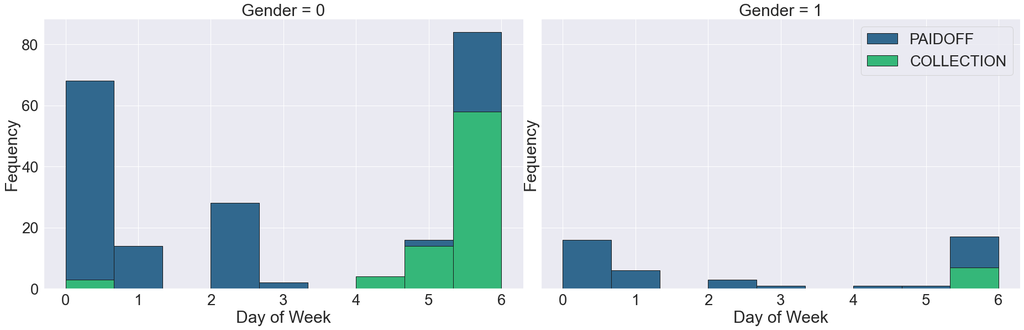

```python
df['dayofweek'] = df['effective_date'].dt.dayofweek
bins = np.linspace(df.dayofweek.min(), df.dayofweek.max(), 10)
sns.set(font_scale = 2.5)
g = sns.FacetGrid(df,
                  col = "Gender",
                  hue = "loan_status",
                  palette = "viridis",
                  col_wrap = 2,
                  height = 9,
                  aspect = 13 / 9)
g.map(plt.hist,
      'dayofweek',
      bins = bins,
      ec = "k")
g.set(xlabel = "Day of Week",
      ylabel = "Fequency")
g.axes[-1].legend();
```

Categorize days by being a weekend or not.

```python
df['Weekend'] = df['dayofweek'].apply(lambda x: 1 if (x > 3) else 0)
df.head()
```

|  | Unnamed: 0 | Unnamed: 0.1 | loan_status | Principal | terms | effective_date | due_date | age | education | Gender | dayofweek | Weekend |
| --- | --- | --- | --- | --- | --- | --- | --- | --- | --- | --- | --- | --- |
| 0 | 0 | 0 | PAIDOFF | 1000 | 30 | 2016-09-08 | 2016-10-07 | 45 | High School or Below | 0 | 3 | 0 |
| 1 | 2 | 2 | PAIDOFF | 1000 | 30 | 2016-09-08 | 2016-10-07 | 33 | Bechalor | 1 | 3 | 0 |
| 2 | 3 | 3 | PAIDOFF | 1000 | 15 | 2016-09-08 | 2016-09-22 | 27 | college | 0 | 3 | 0 |
| 3 | 4 | 4 | PAIDOFF | 1000 | 30 | 2016-09-09 | 2016-10-08 | 28 | college | 1 | 4 | 1 |
| 4 | 6 | 6 | PAIDOFF | 1000 | 30 | 2016-09-09 | 2016-10-08 | 29 | college | 0 | 4 | 1 |

### 4. Education

Education has four categories.

```python
df.groupby(['education'])['loan_status'].value_counts(normalize = True)
```

```
education             loan_status
Bechalor              PAIDOFF        0.750000
                      COLLECTION     0.250000
High School or Below  PAIDOFF        0.741722
                      COLLECTION     0.258278
Master or Above       COLLECTION     0.500000
                      PAIDOFF        0.500000
college               PAIDOFF        0.765101
                      COLLECTION     0.234899
Name: loan_status, dtype: float64
```

### 5. Feature Selection

```python
Feature = df[['Principal','terms','age','Gender','Weekend']]
#Convert 'education' to dummy variables.
Feature = pd.concat([Feature, pd.get_dummies(df['education'])], axis = 1)
Feature.drop(['Master or Above'], axis = 1, inplace = True)
#Rename columns.
Feature.rename(columns = {'terms': 'Terms',
                          'age': 'Age',
                          'Bechalor': 'Bachelor',
                          'college': 'College'},
               inplace = True)
Feature.head()
```

|  | Principal | Terms | Age | Gender | Weekend | Bachelor | High School or Below | College |
| --- | --- | --- | --- | --- | --- | --- | --- | --- |
| 0 | 1000 | 30 | 45 | 0 | 0 | 0 | 1 | 0 |
| 1 | 1000 | 30 | 33 | 1 | 0 | 1 | 0 | 0 |
| 2 | 1000 | 15 | 27 | 0 | 0 | 0 | 0 | 1 |
| 3 | 1000 | 30 | 28 | 1 | 1 | 0 | 0 | 1 |
| 4 | 1000 | 30 | 29 | 0 | 1 | 0 | 0 | 1 |

### 6. Normalize Data

```python
X = Feature
y = df['loan_status'].values
X = preprocessing.StandardScaler().fit(X).transform(X)
```

## III. Classification

### 1. Packages

```python
from sklearn.model_selection import validation_curve as VC
from sklearn.neighbors import KNeighborsClassifier as KNC
from sklearn.ensemble import RandomForestClassifier
from sklearn import metrics
from sklearn import svm
from sklearn.model_selection import GridSearchCV
from sklearn.linear_model import LogisticRegression as LR
```

### 2. K-Nearest Neighbor(KNN)

For K-Nearest Neighbors, I choose a 5-fold cross-validation split across 1 to 70 neighbors.

```python
k_neighbors = list(range(1, 71))
train_scores, valid_scores = VC(KNC(),
                                X, y,
                                param_name = 'n_neighbors',
                                param_range = k_neighbors,
                                cv = 5)
train_knn = []
valid_knn = []

for k in range(70) :
    train_knn.append(sum(train_scores[k]) / 5)
    valid_knn.append(sum(valid_scores[k]) / 5)
```

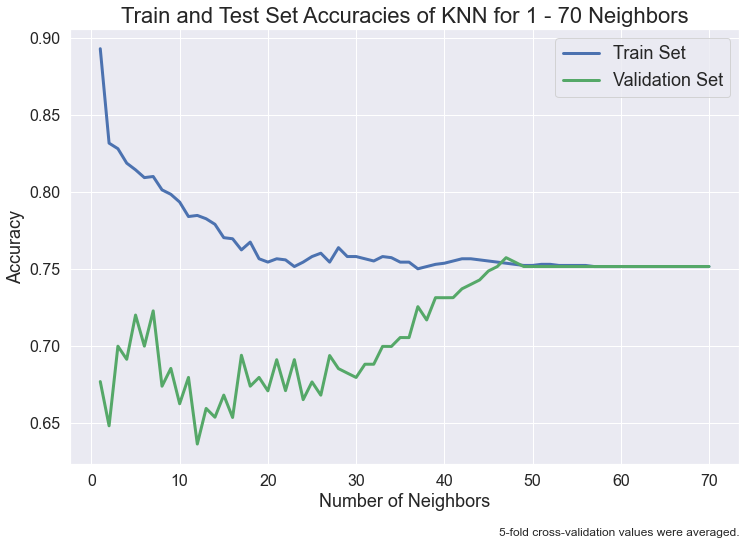

```python
fig, ax = plt.subplots(figsize=(12, 8))
ax.plot(k_neighbors,
        train_knn,
        c = 'b',
        lw = 3,
        label = "Train Set")
ax.plot(k_neighbors,
        valid_knn,
        c = 'g',
        lw = 3,
        label = "Validation Set")

ax.set_title("Train and Test Set Accuracies of KNN for 1 - 70 Neighbors", fontsize = 22)
ax.set_xlabel(xlabel = "Number of Neighbors", fontsize = 18)
ax.set_ylabel(ylabel = "Accuracy", fontsize = 18)
ax.tick_params(axis = 'both', labelsize = 16)
ax.legend(fontsize = 18)
plt.figtext(0.9, 0, "5-fold cross-validation values were averaged.", ha = 'right', fontsize = 12);
```

Using approximately 50 nearest neighbors or more yields a converged accuracy of about 0.75 for the train and validation sets.

```python
knn_model_final = KNC(n_neighbors = 50).fit(X, y)
metrics.accuracy_score(y, knn_model_final.predict(X))
```

```
0.7456647398843931
```

### 3. Decision Tree (Random Forest)

Because the training data set is small, I decided to use Random Forest to optimize. Random Forests are a collection of Decision Trees used to build a final model. A single decision tree is computed very quickly, however it is prone to overfitting. Random Forest calculates the importance of the features from the many trees used to create it.

I created a Random Forest from 30 Decision Trees.

```python
dtrf_model_final = RandomForestClassifier(n_estimators = 30, max_depth = 10, random_state = 3333).fit(X, y)
metrics.accuracy_score(y, dtrf_model_final.predict(X))
```

```
0.8872832369942196
```

### 4. Support Vector Machine

Similar to the KNN model, I used the average accuracy from 5-fold cross-validation.

```python
C_list = [10**n for n in range(-5, 5)]
gamma_list = [10**n for n in range(-7, 0)]
param_grid = {'C': C_list,
              'gamma': gamma_list}

grid = GridSearchCV(svm.SVC(),
                    param_grid,
                    cv = 5,
                    refit = True,
                    verbose = 0).fit(X, y)
```

```python
grid.best_params_
```

```
{'C': 1e-05, 'gamma': 1e-07}
```

The GridSearch algorithm yields that the best hyperparameters are $C = 10^{-5}$ and $γ = 10^{-7}$.

However, these are the respective minimal values for both $C$ and $γ$.

Here is a look at the accuracy of all models from the Grid Search sorted by the hyperparameters.

```python
df_grid = pd.DataFrame(data = grid.cv_results_['mean_test_score'].reshape(10, 7),
                       index = C_list,
                       columns = gamma_list)
df_grid
```

|  | 1.000000e-07 | 1.000000e-06 | 1.000000e-05 | 1.000000e-04 | 1.000000e-03 | 1.000000e-02 | 1.000000e-01 |
| --- | --- | --- | --- | --- | --- | --- | --- |
| 0.00001 | 0.75147 | 0.75147 | 0.751470 | 0.751470 | 0.751470 | 0.751470 | 0.751470 |
| 0.00010 | 0.75147 | 0.75147 | 0.751470 | 0.751470 | 0.751470 | 0.751470 | 0.751470 |
| 0.00100 | 0.75147 | 0.75147 | 0.751470 | 0.751470 | 0.751470 | 0.751470 | 0.751470 |
| 0.01000 | 0.75147 | 0.75147 | 0.751470 | 0.751470 | 0.751470 | 0.751470 | 0.751470 |
| 0.10000 | 0.75147 | 0.75147 | 0.751470 | 0.751470 | 0.751470 | 0.751470 | 0.751470 |
| 1.00000 | 0.75147 | 0.75147 | 0.751470 | 0.751470 | 0.751470 | 0.751470 | 0.708282 |
| 10.00000 | 0.75147 | 0.75147 | 0.751470 | 0.751470 | 0.751470 | 0.633126 | 0.647867 |
| 100.00000 | 0.75147 | 0.75147 | 0.751470 | 0.751470 | 0.615942 | 0.635901 | 0.647867 |
| 1000.00000 | 0.75147 | 0.75147 | 0.751470 | 0.633333 | 0.627329 | 0.653416 | 0.670973 |
| 10000.00000 | 0.75147 | 0.75147 | 0.636232 | 0.639130 | 0.633043 | 0.676770 | 0.673954 |

The accuracy scores from all combinations of $C$ (rows) and $γ$ (columns) are shown above. We can see that the vast majority of cells except those in the bottom right corner have the same accuracy score to 6 decimal places, that is, $0.751470$.

I used $C = 10^{-5}$ and $γ = 10^{-7}$ for the final model.

```python
svm_model_final = svm.SVC(C = 1e-5, gamma = 1e-7, kernel = 'rbf').fit(X, y)
metrics.accuracy_score(y, svm_model_final.predict(X))
```

```
0.7514450867052023
```

### 5. Logistic Regression

```python
train_scores, valid_scores = VC(LR(),
                                X, y,
                                param_name = 'C',
                                param_range = C_list,
                                cv = 5)

train_lr = []
valid_lr = []

for c in range(len(C_list)) :
    train_lr.append(sum(train_scores[c]) / 5)
    valid_lr.append(sum(valid_scores[c]) / 5)
```

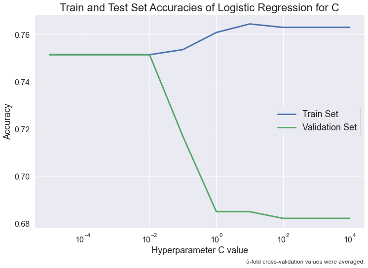

```python
fig, ax = plt.subplots(figsize=(12, 8))
ax.plot(C_list,
        train_lr,
        c = 'b',
        lw = 3,
        label = "Train Set")
ax.plot(C_list,
        valid_lr,
        c = 'g',
        lw = 3,
        label = "Validation Set")

ax.set_title("Train and Test Set Accuracies of Logistic Regression for C", fontsize = 22)
ax.set_xlabel(xlabel = "Hyperparameter C value", fontsize = 18)
ax.set_xscale('log')
ax.set_ylabel(ylabel = "Accuracy", fontsize = 18)
ax.tick_params(axis = 'both', labelsize = 16)
ax.legend(fontsize = 18, loc = 'center right')
plt.figtext(0.9, 0, "5-fold cross-validation values were averaged.", ha = 'right', fontsize = 12);
```

Any $C ≤ 10^{-2}$ from our graph yields an accuracy of approximately 0.75 for the training and test sets.

```python
lr_model_final = LR(C = 1e-4).fit(X,y)
metrics.accuracy_score(y, lr_model_final.predict(X))
```

```
0.7514450867052023
```

## IV. Test Set Results

### 1. Packages

```python
from sklearn.metrics import jaccard_score as js
from sklearn.metrics import f1_score as fs
from sklearn.metrics import log_loss as ll
```

### 2. Test Set

The same steps are repeated from the train set.

#### a. Load

```python
url = "https://s3-api.us-geo.objectstorage.softlayer.net/cf-courses-data/CognitiveClass/ML0101ENv3/labs/loan_test.csv"
filename = wget.download(url)
df_test = pd.read_csv(filename)
df_test.head()
```

```
100% [................................................................................] 3642 / 3642
```

|  | Unnamed: 0 | Unnamed: 0.1 | loan_status | Principal | terms | effective_date | due_date | age | education | Gender |
| --- | --- | --- | --- | --- | --- | --- | --- | --- | --- | --- |
| 0 | 1 | 1 | PAIDOFF | 1000 | 30 | 9/8/2016 | 10/7/2016 | 50 | Bechalor | female |
| 1 | 5 | 5 | PAIDOFF | 300 | 7 | 9/9/2016 | 9/15/2016 | 35 | Master or Above | male |
| 2 | 21 | 21 | PAIDOFF | 1000 | 30 | 9/10/2016 | 10/9/2016 | 43 | High School or Below | female |
| 3 | 24 | 24 | PAIDOFF | 1000 | 30 | 9/10/2016 | 10/9/2016 | 26 | college | male |
| 4 | 35 | 35 | PAIDOFF | 800 | 15 | 9/11/2016 | 9/25/2016 | 29 | Bechalor | male |

#### b. Pre-Process

```python
df_test['effective_date'] = pd.to_datetime(df_test['effective_date'])
df_test['dayofweek'] = df_test['effective_date'].dt.dayofweek
df_test['Weekend'] = df_test['dayofweek'].apply(lambda x: 1 if (x>3)  else 0)
df_test['Gender'].replace(to_replace = ['male', 'female'], value = [0, 1], inplace=True)
```

#### c. Feature Selection

```python
Feature_test = df_test[['Principal','terms','age','Gender','Weekend']]
Feature_test = pd.concat([Feature_test, pd.get_dummies(df_test['education'])], axis = 1)
Feature_test.drop(['Master or Above'], axis = 1, inplace = True)
Feature_test.rename(columns = {'terms': 'Terms',
                               'age': 'Age',
                               'Bechalor': 'Bachelor',
                               'college': 'College'},
                    inplace = True)
```

#### d. Normalize Data

```python
X_test = Feature_test
y_test = df_test['loan_status']
X_test = preprocessing.StandardScaler().fit(X_test).transform(X_test)
```

### 3. Scoring

Using the test set, the Jaccard score and F1 score will be calculated for each of the K-Nearest Neighbors model, Decision Tree (Random Forest) model, Support Vector Machine model, and Logistic Regression model. In addition, the log loss will be calculated for the Logistic Regression model.

```python
#Initialize lists.
models = [knn_model_final, dtrf_model_final, svm_model_final, lr_model_final]
jaccard = []
f1s = []
log_loss = ["NA", "NA", "NA"]

#Calculate scores from each model and append to lists.
for model in models :
    y_pred = model.predict(X_test)
    jaccard.append(js(y_test, y_pred, average = 'micro'))
    f1s.append(fs(y_test, y_pred, average = 'micro'))
    if model == lr_model_final :
        log_loss.append(ll(y_test, model.predict_proba(X_test)))

#Output dataframe.
data = {"Algorithm": ["K-Nearest Neighbors", "Decision Tree/Random Forest", "Support Vector Machine", "Logistic Regression"],
        "Jaccard": jaccard,
        "F1-Score": f1s,
        "Log Loss": log_loss}

report = pd.DataFrame(data = data)
report.set_index("Algorithm")
```

| Algorithm | Jaccard | F1-Score | Log Loss |
| --- | --- | --- | --- |
| K-Nearest Neighbors | 0.636364 | 0.777778 | NA |
| Decision Tree/Random Forest | 0.588235 | 0.740741 | NA |
| Support Vector Machine | 0.588235 | 0.740741 | NA |
| Logistic Regression | 0.588235 | 0.740741 | 0.571405 |

It is important to note that this was an extremely small data set, with only 346 observations in the train set and 54 observations in the test set. A larger sample would possible give better scores and accuracy.

# V. Appendix

#### Complete original train set.

```python
pd.set_option("display.max_rows", None, "display.max_columns", None)

pd.read_csv('loan_train.csv')
```

|  | Unnamed: 0 | Unnamed: 0.1 | loan_status | Principal | terms | effective_date | due_date | age | education | Gender |
| --- | --- | --- | --- | --- | --- | --- | --- | --- | --- | --- |
| 0 | 0 | 0 | PAIDOFF | 1000 | 30 | 9/8/2016 | 10/7/2016 | 45 | High School or Below | male |
| 1 | 2 | 2 | PAIDOFF | 1000 | 30 | 9/8/2016 | 10/7/2016 | 33 | Bechalor | female |
| 2 | 3 | 3 | PAIDOFF | 1000 | 15 | 9/8/2016 | 9/22/2016 | 27 | college | male |
| 3 | 4 | 4 | PAIDOFF | 1000 | 30 | 9/9/2016 | 10/8/2016 | 28 | college | female |
| 4 | 6 | 6 | PAIDOFF | 1000 | 30 | 9/9/2016 | 10/8/2016 | 29 | college | male |
| 5 | 7 | 7 | PAIDOFF | 1000 | 30 | 9/9/2016 | 10/8/2016 | 36 | college | male |
| 6 | 8 | 8 | PAIDOFF | 1000 | 30 | 9/9/2016 | 10/8/2016 | 28 | college | male |
| 7 | 9 | 9 | PAIDOFF | 800 | 15 | 9/10/2016 | 9/24/2016 | 26 | college | male |
| 8 | 10 | 10 | PAIDOFF | 300 | 7 | 9/10/2016 | 9/16/2016 | 29 | college | male |
| 9 | 11 | 11 | PAIDOFF | 1000 | 15 | 9/10/2016 | 10/9/2016 | 39 | High School or Below | male |
| 10 | 12 | 12 | PAIDOFF | 1000 | 30 | 9/10/2016 | 10/9/2016 | 26 | college | male |
| 11 | 13 | 13 | PAIDOFF | 900 | 7 | 9/10/2016 | 9/16/2016 | 26 | college | female |
| 12 | 14 | 14 | PAIDOFF | 1000 | 7 | 9/10/2016 | 9/16/2016 | 27 | High School or Below | male |
| 13 | 15 | 15 | PAIDOFF | 800 | 15 | 9/10/2016 | 9/24/2016 | 26 | college | male |
| 14 | 16 | 16 | PAIDOFF | 1000 | 30 | 9/10/2016 | 10/9/2016 | 40 | High School or Below | male |
| 15 | 17 | 17 | PAIDOFF | 1000 | 15 | 9/10/2016 | 9/24/2016 | 32 | High School or Below | male |
| 16 | 18 | 18 | PAIDOFF | 1000 | 30 | 9/10/2016 | 10/9/2016 | 32 | High School or Below | male |
| 17 | 19 | 19 | PAIDOFF | 800 | 30 | 9/10/2016 | 10/9/2016 | 26 | college | male |
| 18 | 20 | 20 | PAIDOFF | 1000 | 30 | 9/10/2016 | 10/9/2016 | 26 | college | male |
| 19 | 22 | 22 | PAIDOFF | 1000 | 30 | 9/10/2016 | 10/9/2016 | 25 | High School or Below | male |
| 20 | 23 | 23 | PAIDOFF | 1000 | 15 | 9/10/2016 | 9/24/2016 | 26 | college | male |
| 21 | 25 | 25 | PAIDOFF | 1000 | 30 | 9/10/2016 | 10/9/2016 | 29 | High School or Below | male |
| 22 | 26 | 26 | PAIDOFF | 800 | 15 | 9/10/2016 | 9/24/2016 | 39 | Bechalor | male |
| 23 | 27 | 27 | PAIDOFF | 1000 | 15 | 9/10/2016 | 9/24/2016 | 34 | Bechalor | male |
| 24 | 28 | 28 | PAIDOFF | 1000 | 30 | 9/11/2016 | 10/10/2016 | 31 | college | male |
| 25 | 29 | 29 | PAIDOFF | 1000 | 30 | 9/11/2016 | 10/10/2016 | 33 | college | male |
| 26 | 30 | 30 | PAIDOFF | 800 | 15 | 9/11/2016 | 9/25/2016 | 33 | High School or Below | male |
| 27 | 31 | 31 | PAIDOFF | 1000 | 30 | 9/11/2016 | 10/10/2016 | 37 | college | male |
| 28 | 32 | 32 | PAIDOFF | 1000 | 30 | 9/11/2016 | 10/10/2016 | 27 | college | male |
| 29 | 33 | 33 | PAIDOFF | 1000 | 30 | 9/11/2016 | 10/10/2016 | 37 | college | male |

[output cut: 316 more lines]

#### Complete original test set.

```python
pd.read_csv('loan_test.csv')
```

|  | Unnamed: 0 | Unnamed: 0.1 | loan_status | Principal | terms | effective_date | due_date | age | education | Gender |
| --- | --- | --- | --- | --- | --- | --- | --- | --- | --- | --- |
| 0 | 1 | 1 | PAIDOFF | 1000 | 30 | 9/8/2016 | 10/7/2016 | 50 | Bechalor | female |
| 1 | 5 | 5 | PAIDOFF | 300 | 7 | 9/9/2016 | 9/15/2016 | 35 | Master or Above | male |
| 2 | 21 | 21 | PAIDOFF | 1000 | 30 | 9/10/2016 | 10/9/2016 | 43 | High School or Below | female |
| 3 | 24 | 24 | PAIDOFF | 1000 | 30 | 9/10/2016 | 10/9/2016 | 26 | college | male |
| 4 | 35 | 35 | PAIDOFF | 800 | 15 | 9/11/2016 | 9/25/2016 | 29 | Bechalor | male |
| 5 | 37 | 37 | PAIDOFF | 700 | 15 | 9/11/2016 | 9/25/2016 | 33 | High School or Below | male |
| 6 | 38 | 38 | PAIDOFF | 1000 | 15 | 9/11/2016 | 9/25/2016 | 24 | college | male |
| 7 | 48 | 48 | PAIDOFF | 1000 | 30 | 9/11/2016 | 10/10/2016 | 32 | Bechalor | male |
| 8 | 50 | 50 | PAIDOFF | 800 | 15 | 9/11/2016 | 9/25/2016 | 27 | college | female |
| 9 | 61 | 61 | PAIDOFF | 1000 | 15 | 9/11/2016 | 9/25/2016 | 37 | college | male |
| 10 | 64 | 64 | PAIDOFF | 800 | 15 | 9/11/2016 | 9/25/2016 | 24 | High School or Below | male |
| 11 | 68 | 68 | PAIDOFF | 300 | 7 | 9/11/2016 | 9/17/2016 | 35 | college | male |
| 12 | 76 | 76 | PAIDOFF | 1000 | 30 | 9/11/2016 | 10/10/2016 | 31 | Bechalor | male |
| 13 | 78 | 78 | PAIDOFF | 1000 | 30 | 9/11/2016 | 10/10/2016 | 37 | college | female |
| 14 | 84 | 84 | PAIDOFF | 1000 | 30 | 9/11/2016 | 10/10/2016 | 37 | High School or Below | female |
| 15 | 85 | 85 | PAIDOFF | 1000 | 30 | 9/11/2016 | 11/9/2016 | 33 | college | male |
| 16 | 88 | 88 | PAIDOFF | 800 | 15 | 9/11/2016 | 9/25/2016 | 43 | Bechalor | male |
| 17 | 91 | 91 | PAIDOFF | 1000 | 7 | 9/11/2016 | 9/17/2016 | 32 | Bechalor | female |
| 18 | 96 | 96 | PAIDOFF | 1000 | 15 | 9/11/2016 | 9/25/2016 | 26 | High School or Below | male |
| 19 | 100 | 100 | PAIDOFF | 1000 | 7 | 9/11/2016 | 9/17/2016 | 29 | High School or Below | male |
| 20 | 105 | 105 | PAIDOFF | 1000 | 30 | 9/11/2016 | 10/10/2016 | 30 | college | male |
| 21 | 142 | 142 | PAIDOFF | 1000 | 7 | 9/11/2016 | 9/17/2016 | 27 | High School or Below | male |
| 22 | 147 | 147 | PAIDOFF | 300 | 7 | 9/12/2016 | 9/18/2016 | 37 | Master or Above | male |
| 23 | 150 | 150 | PAIDOFF | 1000 | 15 | 9/12/2016 | 10/26/2016 | 29 | college | male |
| 24 | 156 | 156 | PAIDOFF | 1000 | 15 | 9/12/2016 | 9/26/2016 | 26 | Bechalor | male |
| 25 | 167 | 167 | PAIDOFF | 800 | 30 | 9/12/2016 | 10/11/2016 | 28 | college | male |
| 26 | 169 | 169 | PAIDOFF | 1000 | 30 | 9/12/2016 | 10/11/2016 | 38 | college | male |
| 27 | 179 | 179 | PAIDOFF | 1000 | 30 | 9/12/2016 | 10/11/2016 | 46 | college | male |
| 28 | 186 | 186 | PAIDOFF | 1000 | 30 | 9/12/2016 | 10/11/2016 | 33 | Bechalor | male |
| 29 | 196 | 196 | PAIDOFF | 1000 | 30 | 9/12/2016 | 11/10/2016 | 29 | college | male |
| 30 | 199 | 199 | PAIDOFF | 1000 | 30 | 9/12/2016 | 10/11/2016 | 29 | college | male |
| 31 | 202 | 202 | PAIDOFF | 1000 | 15 | 9/12/2016 | 9/26/2016 | 36 | High School or Below | male |
| 32 | 222 | 222 | PAIDOFF | 1000 | 30 | 9/12/2016 | 11/10/2016 | 29 | college | male |
| 33 | 236 | 236 | PAIDOFF | 1000 | 30 | 9/12/2016 | 10/11/2016 | 30 | college | male |
| 34 | 239 | 239 | PAIDOFF | 1000 | 15 | 9/12/2016 | 9/26/2016 | 36 | High School or Below | male |
| 35 | 251 | 251 | PAIDOFF | 1000 | 30 | 9/13/2016 | 10/12/2016 | 29 | college | male |
| 36 | 252 | 252 | PAIDOFF | 1000 | 30 | 9/13/2016 | 10/12/2016 | 28 | High School or Below | male |
| 37 | 264 | 264 | PAIDOFF | 800 | 15 | 9/13/2016 | 9/27/2016 | 23 | college | male |
| 38 | 287 | 287 | PAIDOFF | 1000 | 30 | 9/14/2016 | 10/13/2016 | 38 | High School or Below | female |
| 39 | 295 | 295 | PAIDOFF | 1000 | 30 | 9/14/2016 | 10/13/2016 | 30 | college | female |
| 40 | 302 | 302 | COLLECTION | 1000 | 30 | 9/9/2016 | 10/8/2016 | 33 | High School or Below | male |
| 41 | 305 | 305 | COLLECTION | 1000 | 15 | 9/10/2016 | 9/24/2016 | 31 | High School or Below | female |
| 42 | 309 | 309 | COLLECTION | 800 | 15 | 9/10/2016 | 9/24/2016 | 41 | college | male |
| 43 | 310 | 310 | COLLECTION | 1000 | 30 | 9/10/2016 | 10/9/2016 | 30 | college | male |
| 44 | 311 | 311 | COLLECTION | 800 | 15 | 9/10/2016 | 9/24/2016 | 26 | High School or Below | female |
| 45 | 313 | 313 | COLLECTION | 1000 | 30 | 9/10/2016 | 10/9/2016 | 20 | High School or Below | male |
| 46 | 315 | 315 | COLLECTION | 1000 | 15 | 9/10/2016 | 10/9/2016 | 26 | High School or Below | male |
| 47 | 328 | 328 | COLLECTION | 1000 | 30 | 9/11/2016 | 10/10/2016 | 24 | High School or Below | female |
| 48 | 331 | 331 | COLLECTION | 800 | 15 | 9/11/2016 | 9/25/2016 | 27 | college | male |
| 49 | 348 | 348 | COLLECTION | 1000 | 30 | 9/11/2016 | 10/10/2016 | 32 | High School or Below | male |
| 50 | 349 | 349 | COLLECTION | 800 | 15 | 9/11/2016 | 9/25/2016 | 29 | college | male |
| 51 | 369 | 369 | COLLECTION | 1000 | 30 | 9/11/2016 | 10/10/2016 | 37 | High School or Below | male |
| 52 | 370 | 370 | COLLECTION | 800 | 15 | 9/11/2016 | 9/25/2016 | 36 | High School or Below | male |
| 53 | 396 | 396 | COLLECTION | 1000 | 30 | 9/12/2016 | 10/11/2016 | 33 | High School or Below | male |